# Schelling Segregation Model

Dan Conroy-Beam

2024-08-29

## Model Overview

### Purpose

Determine whether segregation can be explained by individual motivations to avoid being a local minority. Agents will move around a two-dimensional space depending on whether they are a racial minority within their local neighborhood.

### Agents

A population of agents will be generated; each agent will have a race (black or white) and a position in a 2-dimensional space.

### Life Cycle

1. Assess
2. Move

#### Assess

Each agent will first calculate how far they are from each other agent in the 2D space. The agent will then identify all agents who reside within a set radius around them. These agents constitute the focal agent’s neighborhood.

The focal agent will then determine the race of all agents in their neighborhood. Finally, the agent will determine whether they are in the minority race in their neighborhood.

#### Move

In this stage of the life cycle, the agent makes one decision: if the agent is not in the minority then they will stay where they are. If the agent is in the minority, they will move to a new random location.

### Analysis

The model will plot the position of agents before and after the movement phases

## Model

### Packages

```r
library(ggplot2)
```

### Parameters

```r
#Population Size#
#Number of agents to generate
popSize<-1000



#Neighborhood Radius#
#The size of the agent's neighborhood
radius<-25



#Minority Threshold#
#The threshold below which an agent will consider themselves a minority
threshold<-.5
```

### Functions

```r
#Agent Generation#
#A function to generate agents
agentGenerate<-function(n){

  #Assign each agent a random race
  race<-sample(c("white","black"),n,replace=T)

  #Assign each agent a random x-position
  xPos<-runif(n,0,100)

  #Assign each agent a random y-position
  yPos<-runif(n,0,100)

  #Put the agents together in a dataframe
  agents<-data.frame(race,xPos,yPos)

  #Output the agents
  return(agents)

}



#Assessment Function#
#A function to have agents decide whether they want to move
assess<-function(agents,radius,threshold){

  #Determine the distance between each agent and every other agent
  distances<-as.matrix(dist(agents[,2:3]))

  #Create a vector to store agent movement decisions
  moveDecision<-rep(NA,nrow(agents))

  #Loop through agents
  for(a in 1:nrow(agents)){

    #Determine which agents are part of agent a's neigbhorhood
    neighbors<-distances[a,]<=radius

    #Determine which agents are of the same race as agent a
    sameRace<-agents$race[a]==agents$race

    #Have the agent assess the proportion of same race neighbors
    assessment<-sum(sameRace & neighbors) / sum(neighbors)

    #Have the agent decide whether they want to move
    moveDecision[a]<-assessment<threshold

  }

  #Output the agents' decisions
  return(moveDecision)

}



#Move#
#A function to move agents to a new location
move<-function(agents,moveDecision){

  #Loop through agents one-by-one...
  for(a in 1:nrow(agents)){

    #If the agent decided to move...
    if(moveDecision[a]==T){

      #...give them a new random X and Y position
      agents$xPos[a]<-runif(1,0,100)
      agents$yPos[a]<-runif(1,0,100)

    }

  }

  #Output the agents
  return(agents)

}
```

### Life Cycle

```r
###Agent Generation###

#Generate the agents
agents<-agentGenerate(popSize)

#Save the agents' starting positions
startData<-agents



###Life Cycle###

#Initialize a moveDecision value to get the while() loop going
moveDecision<-1

#A counter to keep track of while() loops
steps<-0

#The maximum number of while() loops I'll tolerate
maxSteps<-100

#As long as some agent wants to move AND steps is less than maxSteps...
while (sum(moveDecision) > 0 & steps<maxSteps) {

  #Assess#

  #Have the agents decide whether they want to move
  moveDecision <- assess(agents, radius, threshold)


  #Move#

  #Move the agents who decided to move
  agents <- move(agents, moveDecision)

  #Increment the steps variable
  steps<-steps+1

}

#Save the agents' final positions
endData<-agents
```

### Analysis

```r
#Plot agent starting positions
t1plot<-ggplot(data=startData,
               aes(x=xPos,
                   y=yPos,
                   color=race))+
  labs(x="",y="",color="Agent Race")+
  geom_point(size=2.5)+
  scale_color_manual(values=c("black","white"),labels=c("Black","White"))+
  theme(panel.background=element_rect(fill="grey"))



#Plot agent finishing positions
t2plot<-ggplot(data=endData,
               aes(x=xPos,
                   y=yPos,
                   color=race))+
  labs(x="",y="",color="Agent Race")+
  geom_point(size=2.5)+
  scale_color_manual(values=c("black","white"),labels=c("Black","White"))+
  theme(panel.background=element_rect(fill="grey"))
```

Consistent with expectations, agents are are initially not very segregated:

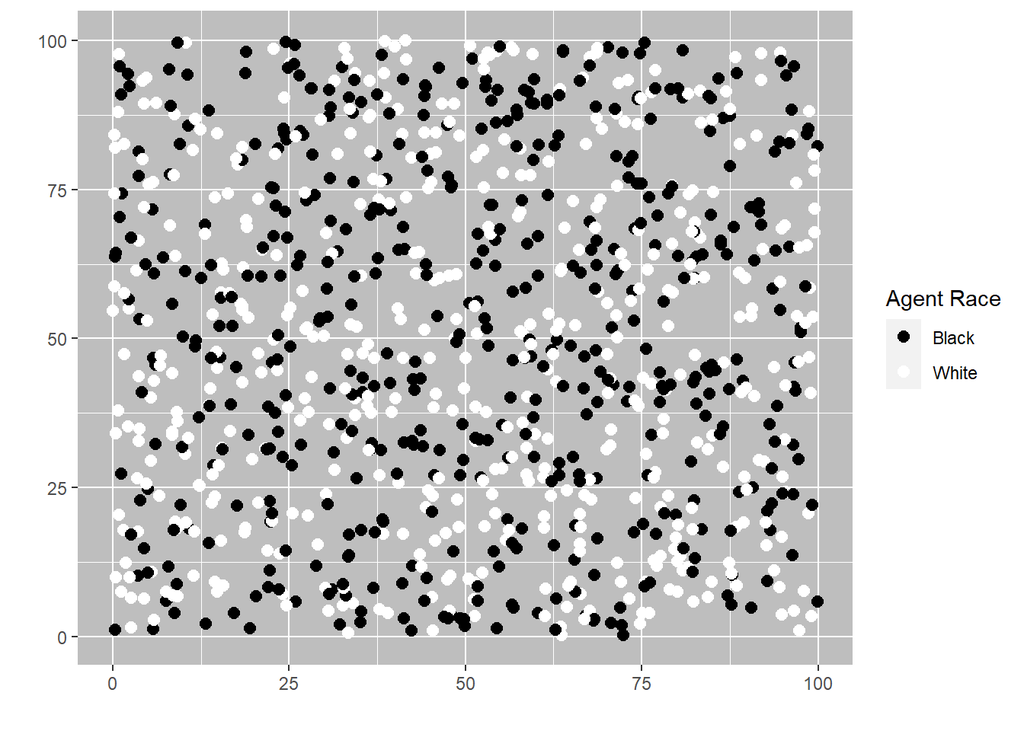

```r
t1plot
```

However, after agents are allowed to move according to their preferences, they spontaneously form highly segregated neighborhoods:

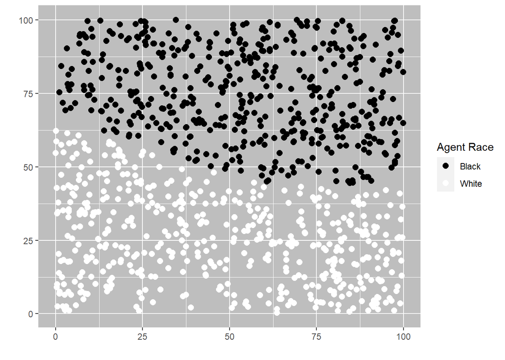

```r
t2plot
```